# EGRMGMT 590.21 Homework 8 (Questions)

### Exercise 9 (10 Points)

- Use the randomForest() function in the randomForest library to build random forest (RF) models with 500 as the constant number of trees and varying mtry (i.e. number of variables randomly sampled as candidates at each split) to predict the customer segment (“Segment”) using other variables in the training data of Exercise 8
- Create a line chart with the mtry (ranging from 1 to 9) as the horizontal axis and the corresponding accuracy rate on the testing data as the vertical axis
- Based on the chart, what is the optimal value of mtry for your RF models?

```r
library(randomForest)
```

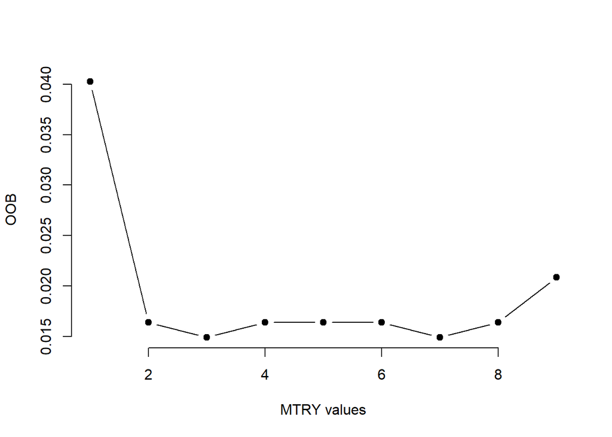

```r
train2 <- sample(train)

q9 <- randomForest(Segment~subscribeToMusic+musicEnthuse+drivingEnthuse+commuteCar+kidsAtHome+milesDrive+householdIncome+sex+age, data = train2, maxnodes = 500 ,)


Forest.train <- predict(q9, train)
Forest.test <- predict(q9,test)

oob.values <- vector(length= 9)

for (k in 1:9) {
 storeitin <- randomForest(Segment~. ,data = train2, mtry = k, ntree= 500 )
 oob.values[k] <- storeitin$err.rate[nrow(storeitin$err.rate),1]

}

k <- 1:9

plot(k, oob.values,
       type="b", pch = 19, frame = FALSE,
       xlab="MTRY values",
       ylab="OOB")
```

```r
#hence the best possible value would be 3 because oob is the lowest
```

### Exercise 10 (10 Points)

- Build a random forest model using the training data of Exercise 8 and the optimal value of mtry identified in Exercise 9
- Use the heatmap.2() function to create a heat map of variable importance by segment
- Based on the heat map, which variable is the most important predictor to identify customers in the “LongDistance” segment?

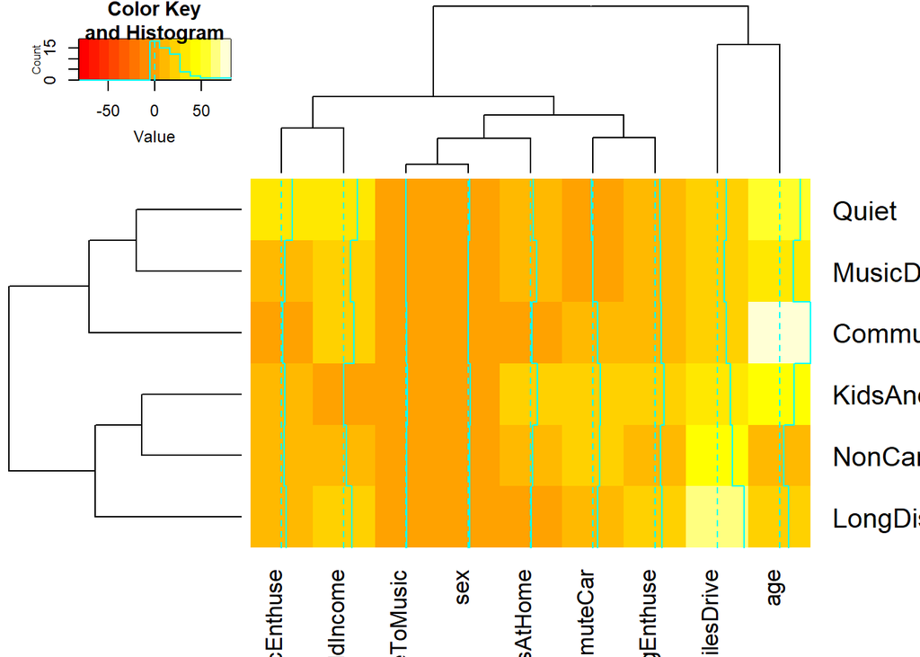

```r
model.for.10 <- randomForest(Segment~subscribeToMusic+musicEnthuse+drivingEnthuse+commuteCar+kidsAtHome+milesDrive+householdIncome+sex+age, data = train, maxnodes = 500 , mtry = 3, importance = TRUE)

library(gplots)
heatmap.2(t(importance(model.for.10)[,1:6]))
```